# GLM Assignment

Sarah Zirkle

September 16, 2021

*Poisson Example*

Bat diversity: The species diversity encountered per year relates to net nights.

In this exampple the response variable is a count and the covariate is a continuous predictor.

```r
bats.glm <- glm(Diversity ~ Effort, data = bats, family = poisson(link = "log"))
summary(bats.glm)
```

```
##
## Call:
## glm(formula = Diversity ~ Effort, family = poisson(link = "log"),
##     data = bats)
##
## Deviance Residuals:
##     Min       1Q   Median       3Q      Max
## -1.7573  -0.4260   0.1361   0.4646   0.8629
##
## Coefficients:
##              Estimate Std. Error z value Pr(>|z|)
## (Intercept) 1.9649309  0.1181771  16.627   <2e-16 ***
## Effort      0.0005177  0.0006308   0.821    0.412
## ---
## Signif. codes:  0 '***' 0.001 '**' 0.01 '*' 0.05 '.' 0.1 ' ' 1
##
## (Dispersion parameter for poisson family taken to be 1)
##
##     Null deviance: 8.3334  on 17  degrees of freedom
## Residual deviance: 7.6950  on 16  degrees of freedom
## AIC: 81.093
##
## Number of Fisher Scoring iterations: 4
```

We can determine 95% CI for the coefficients, calculate exponentiated coefficients, and determine 95% CI for exponentiated coefficients.

```r
confint(bats.glm)
```

```
##                     2.5 %      97.5 %
## (Intercept)  1.7287962374 2.192645099
## Effort      -0.0008043622 0.001680065
```

```r
exp(coef(bats.glm))
```

```
## (Intercept)      Effort
##    7.134420    1.000518
```

```r
exp(confint(bats.glm))
```

```
##                2.5 %   97.5 %
## (Intercept) 5.633868 8.958879
## Effort      0.999196 1.001681
```

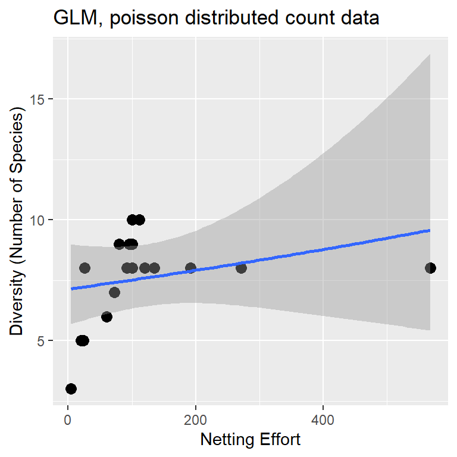

```r
ggplot(bats, aes(Effort, Diversity)) +
  geom_point(size=3) +
  stat_smooth(method = glm, method.args = list(family = poisson(link = "log"))) +
  labs(title="GLM, poisson distributed count data") +
  xlab ("Netting Effort") +
  ylab ("Diversity (Number of Species)")
```

```r
batdiversity.glm <- glm(Diversity ~ Effort, data = bats, family = poisson(link = log))
```

Lets look at the diagnostic plots.

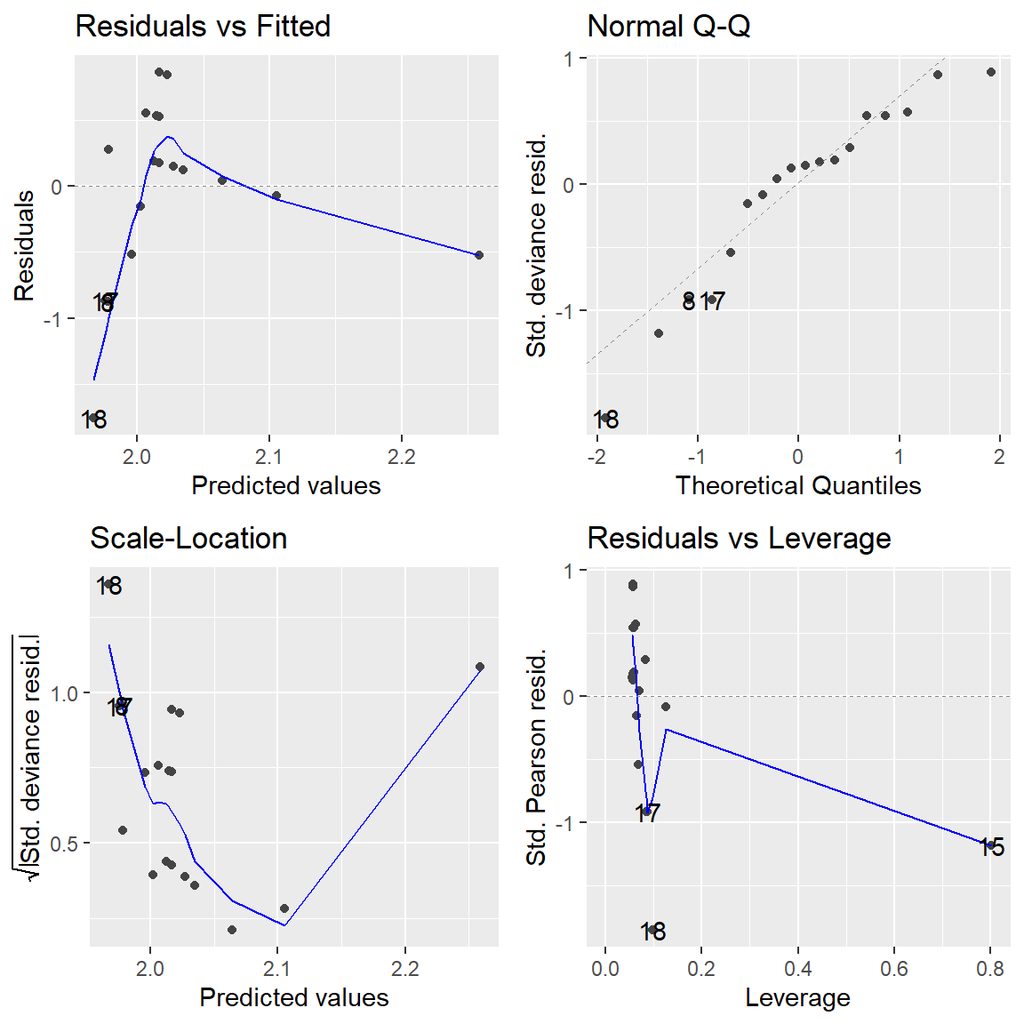

```r
autoplot(batdiversity.glm)
```

```r
anova(batdiversity.glm)
```

```
## Analysis of Deviance Table
##
## Model: poisson, link: log
##
## Response: Diversity
##
## Terms added sequentially (first to last)
##
##
##        Df Deviance Resid. Df Resid. Dev
## NULL                      17     8.3334
## Effort  1  0.63847        16     7.6950
```

```r
summary(batdiversity.glm)
```

```
##
## Call:
## glm(formula = Diversity ~ Effort, family = poisson(link = log),
##     data = bats)
##
## Deviance Residuals:
##     Min       1Q   Median       3Q      Max
## -1.7573  -0.4260   0.1361   0.4646   0.8629
##
## Coefficients:
##              Estimate Std. Error z value Pr(>|z|)
## (Intercept) 1.9649309  0.1181771  16.627   <2e-16 ***
## Effort      0.0005177  0.0006308   0.821    0.412
## ---
## Signif. codes:  0 '***' 0.001 '**' 0.01 '*' 0.05 '.' 0.1 ' ' 1
##
## (Dispersion parameter for poisson family taken to be 1)
##
##     Null deviance: 8.3334  on 17  degrees of freedom
## Residual deviance: 7.6950  on 16  degrees of freedom
## AIC: 81.093
##
## Number of Fisher Scoring iterations: 4
```

What does the report tell us?

If we want to know how many species 140 net nights is predicted to result in, we must account for what the link function did.

What is the expected yearly species diversity for 140 net nights? ANSWER=e^(1.9649309+0.0005177*140), or 7.670708 species.

```r
exp(1.9649309+0.0005177*140)
```

```
## [1] 7.670708
```

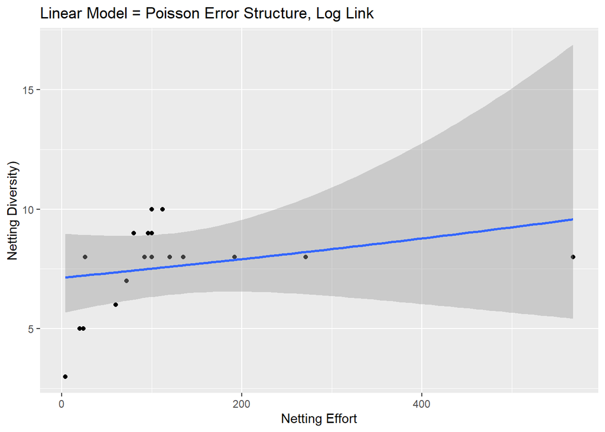

```r
ggplot(bats, aes(x = Effort, y = Diversity)) +
  geom_point() +
  geom_smooth(method="glm", method.args=list(family="poisson"(link="log"))) +
  xlab("Netting Effort") + ylab("Netting Diversity)") +
  ggtitle("Linear Model = Poisson Error Structure, Log Link")
```

*Now, lets remove the outliers from this data set and see if anything changes.*

```r
bats.sub1 <- bats[c(1:11,13:14,17),c(1:3)]
View(bats.sub1)
View(bats)
```

```r
bats.sub1.glm <- glm(Diversity ~ Effort, data = bats.sub1, family = poisson(link = "log"))
summary(bats.sub1.glm)
```

```
##
## Call:
## glm(formula = Diversity ~ Effort, family = poisson(link = "log"),
##     data = bats.sub1)
##
## Deviance Residuals:
##     Min       1Q   Median       3Q      Max
## -0.5654  -0.4204  -0.0931   0.3522   0.6941
##
## Coefficients:
##             Estimate Std. Error z value Pr(>|z|)
## (Intercept) 1.716419   0.261840   6.555 5.56e-11 ***
## Effort      0.004122   0.002832   1.455    0.146
## ---
## Signif. codes:  0 '***' 0.001 '**' 0.01 '*' 0.05 '.' 0.1 ' ' 1
##
## (Dispersion parameter for poisson family taken to be 1)
##
##     Null deviance: 4.5284  on 13  degrees of freedom
## Residual deviance: 2.3419  on 12  degrees of freedom
## AIC: 60.934
##
## Number of Fisher Scoring iterations: 4
```

We can determine 95% CI for the coefficients, calculate exponentiated coefficients, and determine 95% CI for exponentiated coefficients.

```r
confint(bats.sub1.glm)
```

```
##                    2.5 %      97.5 %
## (Intercept)  1.177162168 2.205441034
## Effort      -0.001315775 0.009806091
```

```r
exp(coef(bats.sub1.glm))
```

```
## (Intercept)      Effort
##    5.564568    1.004131
```

```r
exp(confint(bats.sub1.glm))
```

```
##                 2.5 %   97.5 %
## (Intercept) 3.2451519 9.074253
## Effort      0.9986851 1.009854
```

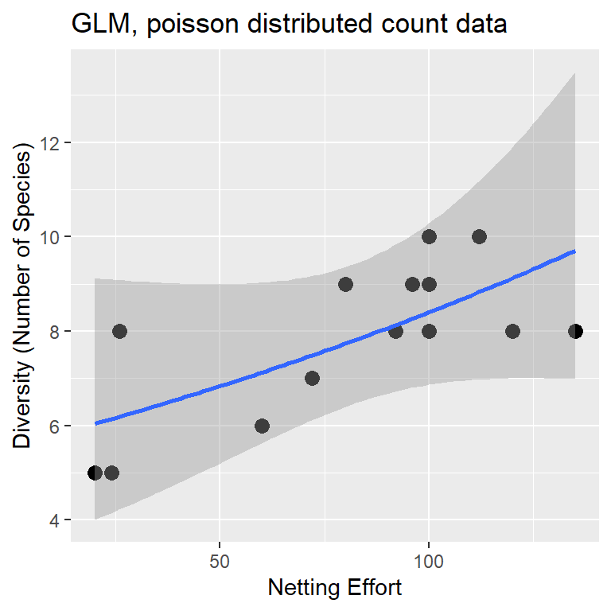

```r
ggplot(bats.sub1, aes(Effort, Diversity)) +
  geom_point(size=3) +
  stat_smooth(method = glm, method.args = list(family = poisson(link = "log"))) +
  labs(title="GLM, poisson distributed count data") +
  xlab ("Netting Effort") +
  ylab ("Diversity (Number of Species)")
```

```r
batdiversity1.glm <- glm(Diversity ~ Effort, data = bats.sub1, family = poisson(link = log))
```

Lets look at the diagnostic plots.

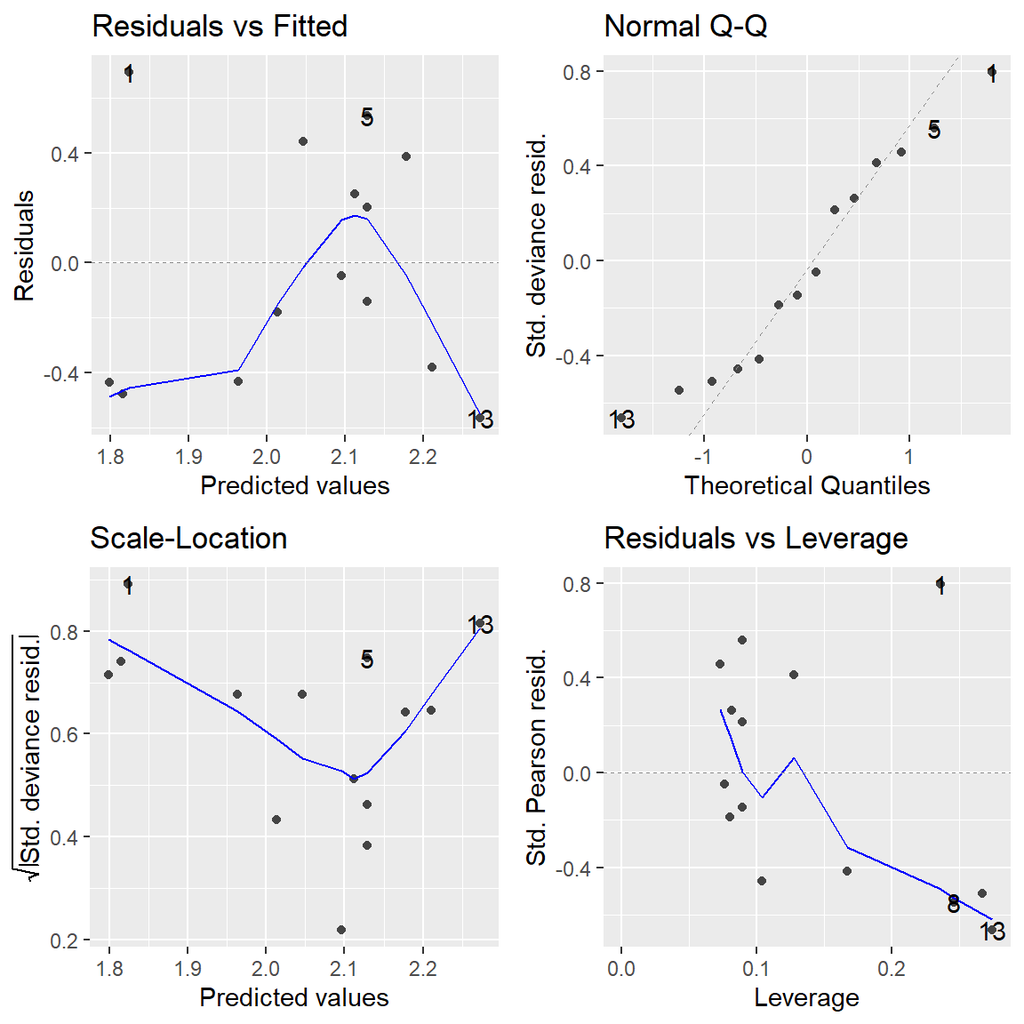

```r
autoplot(batdiversity1.glm)
```

```r
anova(batdiversity1.glm)
```

```
## Analysis of Deviance Table
##
## Model: poisson, link: log
##
## Response: Diversity
##
## Terms added sequentially (first to last)
##
##
##        Df Deviance Resid. Df Resid. Dev
## NULL                      13     4.5284
## Effort  1   2.1865        12     2.3419
```

```r
summary(batdiversity1.glm)
```

```
##
## Call:
## glm(formula = Diversity ~ Effort, family = poisson(link = log),
##     data = bats.sub1)
##
## Deviance Residuals:
##     Min       1Q   Median       3Q      Max
## -0.5654  -0.4204  -0.0931   0.3522   0.6941
##
## Coefficients:
##             Estimate Std. Error z value Pr(>|z|)
## (Intercept) 1.716419   0.261840   6.555 5.56e-11 ***
## Effort      0.004122   0.002832   1.455    0.146
## ---
## Signif. codes:  0 '***' 0.001 '**' 0.01 '*' 0.05 '.' 0.1 ' ' 1
##
## (Dispersion parameter for poisson family taken to be 1)
##
##     Null deviance: 4.5284  on 13  degrees of freedom
## Residual deviance: 2.3419  on 12  degrees of freedom
## AIC: 60.934
##
## Number of Fisher Scoring iterations: 4
```

What does the report tell us?

If we want to know how many species 140 net nights is predicted to result in, we must account for what the link function did.

What is the expected yearly species diversity for 140 net nights? ANSWER=e^(1.716419+0.004122*140), or 9.909551 species.

```r
exp(1.716419+0.004122*140)
```

```
## [1] 9.909551
```

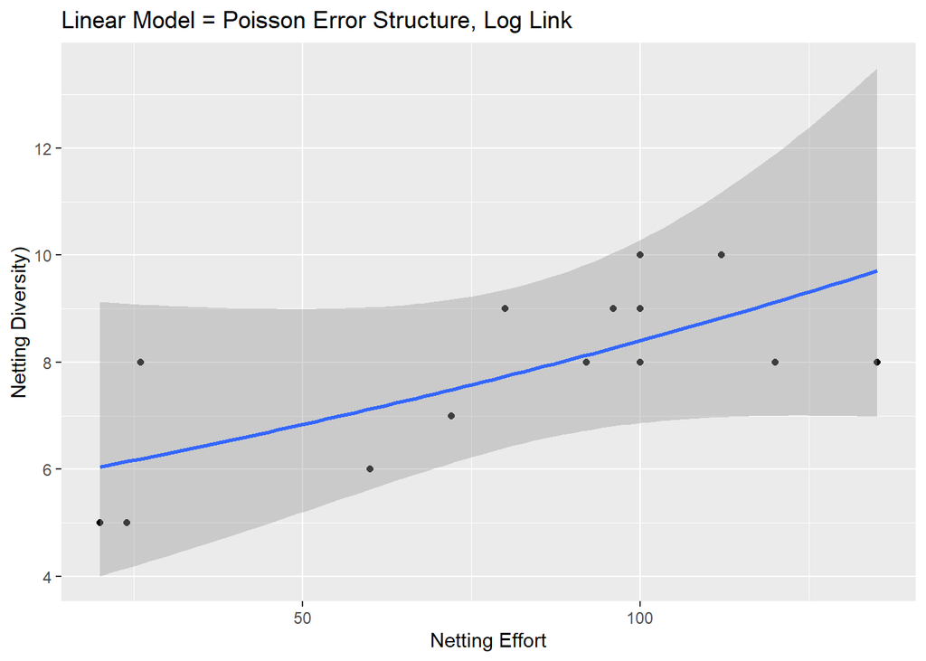

```r
ggplot(bats.sub1, aes(x = Effort, y = Diversity)) +
  geom_point() +
  geom_smooth(method="glm", method.args=list(family="poisson"(link="log"))) +
  xlab("Netting Effort") + ylab("Netting Diversity)") +
  ggtitle("Linear Model = Poisson Error Structure, Log Link")
```

*Binomial example*

```r
habitat <- read.csv("BatHabitatQuery.csv")
View(habitat)
```

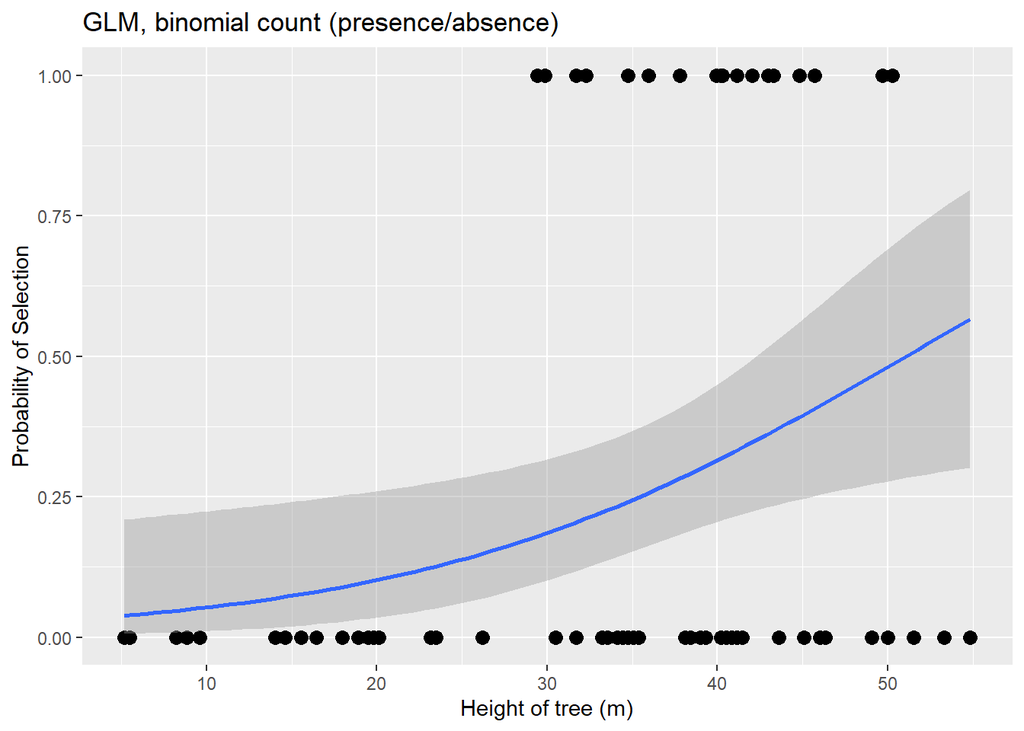

```r
ggplot(habitat, aes(RTHeight, Use)) +
  geom_point(size=3) +
  geom_smooth(method="glm", method.args=list(family="binomial"(link="logit"))) +
  labs(title="GLM, binomial count (presence/absence)") +
  ylab ("Probability of Selection") +
  xlab ("Height of tree (m)")
```

```r
model_habitat <- glm(Use ~ RTHeight, data=habitat, family=binomial)
model_habitat
```

```
##
## Call:  glm(formula = Use ~ RTHeight, family = binomial, data = habitat)
##
## Coefficients:
## (Intercept)     RTHeight
##    -3.58263      0.07012
##
## Degrees of Freedom: 71 Total (i.e. Null);  70 Residual
##   (88 observations deleted due to missingness)
## Null Deviance:       80.98
## Residual Deviance: 73.15     AIC: 77.15
```

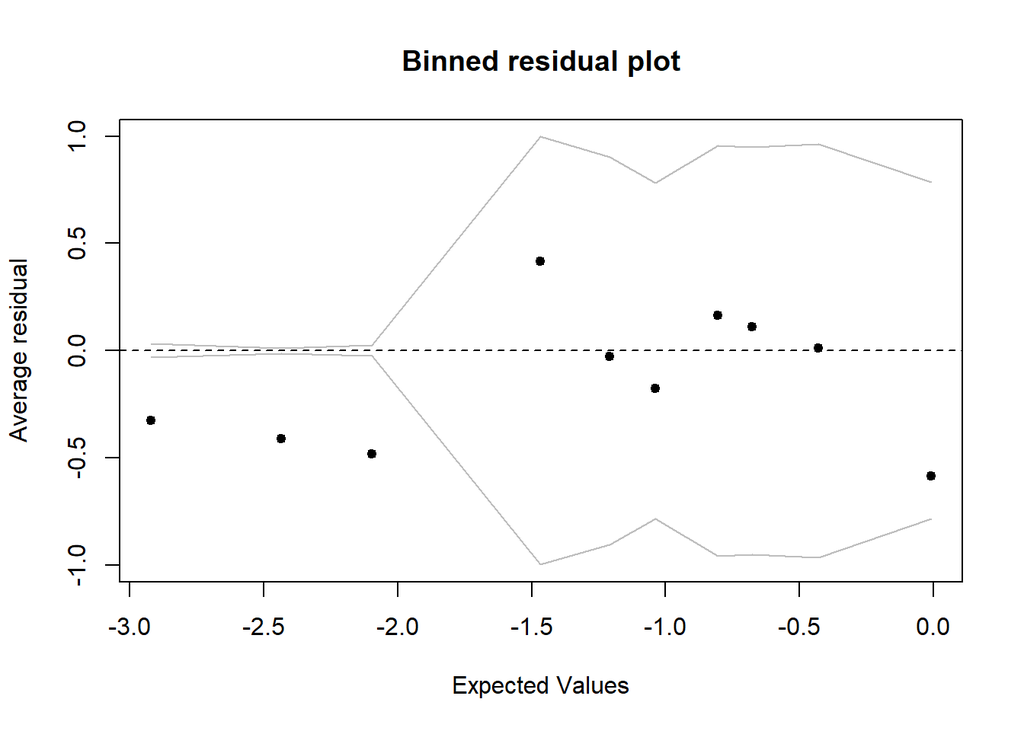

```r
library(arm)
x <- predict(model_habitat)
y <- resid(model_habitat)
binnedplot(x, y)
```

```r
coef(model_habitat)
```

```
## (Intercept)    RTHeight
## -3.58263160  0.07011639
```

```r
confint(model_habitat)
```

```
##                  2.5 %     97.5 %
## (Intercept) -6.0740440 -1.6676356
## RTHeight     0.0194992  0.1321125
```

Interpret the slope of the logistic regression. Dividing the slope coefficient by four will give us an approximate estimate for the maximum predicted effect on the response of a unit change in the predictor. Slope of tree height variable is 0.07011639.  
In this case, a difference in 1 unit of height (m) corresponds to a increase in the probability of switching of 1.75% since 0.07011639/4 = 0.0175291. (*100 to convert to percent=1.75%).

```r
summary(model_habitat)
```

```
##
## Call:
## glm(formula = Use ~ RTHeight, family = binomial, data = habitat)
##
## Deviance Residuals:
##      Min        1Q    Median        3Q       Max
## -1.29136  -0.82395  -0.48906   0.09037   1.85283
##
## Coefficients:
##             Estimate Std. Error z value Pr(>|z|)
## (Intercept) -3.58263    1.10611  -3.239   0.0012 **
## RTHeight     0.07012    0.02827   2.480   0.0131 *
## ---
## Signif. codes:  0 '***' 0.001 '**' 0.01 '*' 0.05 '.' 0.1 ' ' 1
##
## (Dispersion parameter for binomial family taken to be 1)
##
##     Null deviance: 80.976  on 71  degrees of freedom
## Residual deviance: 73.151  on 70  degrees of freedom
##   (88 observations deleted due to missingness)
## AIC: 77.151
##
## Number of Fisher Scoring iterations: 4
```

Thanks!